# Jimmy's Data Science Project For Udacity

```python
# Intro
#
# First, thank you for your patience in my submission. I was so grateful to be given the opportunity to finish this course.
# After a year that saw the loss of close relatives, a hurricane, a trip to Korea, a move across the country,
# visits from relatives, and the holiday season, it felt wonderful to return to Udacity as a student.

print("Thank you so very much")
```

```
Thank you so very much
```

```python
# Dataset Choice

# I went with the TMDB dataset. I like movies and I thought choosing movie data would encourage me to push this project out
# in a quick manner

print("""Dataset:

Movies for the win, woooo""")
```

```
Dataset:

Movies for the win, woooo
```

```python
# Questions

# As I perused the data, I was immediately drawn to popularity, budget, and revenue, probably because they had numbers
# so I knew it would be easy to manipulate in Numpy and Pandas.

# Immediate questions:
# Does budget determine revenue?
# Does budget determine popularity?

# I chose budget as the independent variables in both instances since, you know, revenue probably doesn't cause budget,
# not without distorting the space-time continuum

# I thought there might be a trend between budget and voter count. Movies with higher budget throw money at marketing.
# This encourages awareness and engagement. For laughs, I thought there might also be a relationship between voter count
# and revenue as well.

# Overall, I would imagine collinearity of these variables, but that's outside the scope of the assignment

print("""Questions:

Does budget determine revenue?
Does budget determine popularity?
Is there a relationship between voter count and budget?
Is there a relationship between voter count and revenue?""")
```

```
Questions:

Does budget determine revenue?
Does budget determine popularity?
Is there a relationship between voter count and budget?
Is there a relationship between voter count and revenue?
```

```python
# Investigation

# I did my normal analytics stuff that's fascinated me since high school and that's stupid easy to do in Numpy and Pandas:
# Mean and Standard Deviation of each of the variables I mentioned. I had (got!) to write a function for the tag line question
# Then, I went to the descriptive stats portion, using Pearson's R to see if there was a correlation

print("""Investigation:

Wrote my helper functions, crunched some numbers, spit out the data in a pretty chart""")
```

[output not shown]

[output not shown]

```
Investigation:

Wrote my helper functions, crunched some numbers, spit out the data in a pretty chart
```

```python
# Wrangling

# There were three things I noticed that would have a negative impact on my data:
#  - popularity greater than 10, which shouldn't be possible on a scale of 10
# - budget equal to 0, which is possible, but I felt that these were major productions with some kind of money spent
# - revenue equal to 0, which is also possible, but, again, major productions, even the worst ones, turn some kind of profit

print("""Wrangling:

Removed the bad data
Popularity > 10
Revenue = 0
Budget = 0
Voter Count = 0""")
```

```
Wrangling:

Removed the bad data
Popularity > 10
Revenue = 0
Budget = 0
Voter Count = 0
```

```python
# First we start with the dependencies

import numpy as np
import pandas as pd
import matplotlib.pyplot as plt

print("Successful import of dependencies!")
```

```
Successful import of dependencies!
```

```python
#Helper functions

#Standardize data and Correlation are both from my Udacity Data Science exercises.

#Standardize data
def standardize_data(values):
    '''
    Fill in this function to return a standardized version of the given values,
    which will be in a NumPy array. Each value should be translated into the
    number of standard deviations that value is away from the mean of the data.
    (A positive number indicates a value higher than the mean, and a negative
    number indicates a value lower than the mean.)
    '''
    mean = values.mean()
    dev = values.std(ddof=0)
    return (values-mean)/dev

#Correlation
def correlation(x, y):
    """
    Pull the means and the standard deviations and then use this math rule for the Pearson's coefficient
    correlation = average of (x in standard units) times (y in standard units)

    """
    xmean = x.mean()
    ymean = y.mean()

    xstd = x.std(ddof=0)
    ystd = y.std(ddof=0)

    xstandard = ((x-xmean)/xstd)
    ystandard = ((y-ymean)/ystd)

    cor = (xstandard*ystandard).mean()

    return cor

#Pearson's and Scatterplots
def rAndGraph(l1,l2):
    """
    First, pull the names of the columns using the name propery. Replace any weird characters.
    Get the Pearson's coeffiecient from earlier function
    Prep output for ease of maintenance.
    Apply the logic and add the prefab verbage
    Graph
    """
    n1 = l1.name.replace("_", " ").title()
    n2 = l2.name.replace("_", " ").title()
    c = round(correlation(l1,l2),3)*100
    prefab1 = "As far as " + n1 + " and " + n2 + ", there is "
    prefab2 = "correlation with a value of " + str(c) + "%. Here's the graph: "

    if -25 < c < 25:
        print(prefab1 + "nearly no " + prefab2)
    elif (-50 < c <= -25) or (25 <= c < 50):
        print(prefab1 + "a slight " + prefab2)
    elif (-75 < c <= -50) or (50 <= c < 75):
        print(prefab1 + "some " + prefab2)
    else:
        print(prefab1 + "strong " + prefab2)

    plt.scatter(standardize_data(l1),standardize_data(l2))
    plt.title("Comparing " + n1 + " to " + n2 + " --- Please note: the data is standardized.")
    plt.xlabel(n1)
    plt.ylabel(n2)
    plt.show()


def titleAndDescribe(l1):
    """
    Throw a title and parse the description for ease of reading
    """
    print(l1.name.title())
    print(l1.describe())
    print('\n')
"""
import matplotlib.mlab as mlab

def bellCurve(l1):
    mean = l1.mean()
    std = l1.std()
    x = np.linspace(mean - 4*std, mean + 4*std, 100)
    plt.plot(x,mlab.normpdf(x, mean, std),label=l1.name.title())
    plt.ylabel('Expectation')
    plt.xlabel('Units')
    plt.title(l1.name.title() + " and its Cool Looking Bell Curve! :D :D :D")
    plt.show()
"""

def histogram(series,col):
    series.hist(column=col,bins=100)
    plt.show()
```

```python
# Open the Pandas file

movies = pd.read_csv('tmdb.csv')

print("Here's our movies data!!")
movies.head()
```

```
Here's our movies data!!
```

|  | id | imdb_id | popularity | budget | revenue | original_title | cast | homepage | director | tagline | ... | overview | runtime | genres | production_companies | release_date | vote_count | vote_average | release_year | budget_adj | revenue_adj |
| --- | --- | --- | --- | --- | --- | --- | --- | --- | --- | --- | --- | --- | --- | --- | --- | --- | --- | --- | --- | --- | --- |
| 0 | 135397 | tt0369610 | 32.985763 | 150000000 | 1513528810 | Jurassic World | Chris Pratt\|Bryce Dallas Howard\|Irrfan Khan\|Vi... | http://www.jurassicworld.com/ | Colin Trevorrow | The park is open. | ... | Twenty-two years after the events of Jurassic ... | 124 | Action\|Adventure\|Science Fiction\|Thriller | Universal Studios\|Amblin Entertainment\|Legenda... | 6/9/15 | 5562 | 6.5 | 2015 | 1.379999e+08 | 1.392446e+09 |
| 1 | 76341 | tt1392190 | 28.419936 | 150000000 | 378436354 | Mad Max: Fury Road | Tom Hardy\|Charlize Theron\|Hugh Keays-Byrne\|Nic... | http://www.madmaxmovie.com/ | George Miller | What a Lovely Day. | ... | An apocalyptic story set in the furthest reach... | 120 | Action\|Adventure\|Science Fiction\|Thriller | Village Roadshow Pictures\|Kennedy Miller Produ... | 5/13/15 | 6185 | 7.1 | 2015 | 1.379999e+08 | 3.481613e+08 |
| 2 | 262500 | tt2908446 | 13.112507 | 110000000 | 295238201 | Insurgent | Shailene Woodley\|Theo James\|Kate Winslet\|Ansel... | http://www.thedivergentseries.movie/#insurgent | Robert Schwentke | One Choice Can Destroy You | ... | Beatrice Prior must confront her inner demons ... | 119 | Adventure\|Science Fiction\|Thriller | Summit Entertainment\|Mandeville Films\|Red Wago... | 3/18/15 | 2480 | 6.3 | 2015 | 1.012000e+08 | 2.716190e+08 |
| 3 | 140607 | tt2488496 | 11.173104 | 200000000 | 2068178225 | Star Wars: The Force Awakens | Harrison Ford\|Mark Hamill\|Carrie Fisher\|Adam D... | http://www.starwars.com/films/star-wars-episod... | J.J. Abrams | Every generation has a story. | ... | Thirty years after defeating the Galactic Empi... | 136 | Action\|Adventure\|Science Fiction\|Fantasy | Lucasfilm\|Truenorth Productions\|Bad Robot | 12/15/15 | 5292 | 7.5 | 2015 | 1.839999e+08 | 1.902723e+09 |
| 4 | 168259 | tt2820852 | 9.335014 | 190000000 | 1506249360 | Furious 7 | Vin Diesel\|Paul Walker\|Jason Statham\|Michelle ... | http://www.furious7.com/ | James Wan | Vengeance Hits Home | ... | Deckard Shaw seeks revenge against Dominic Tor... | 137 | Action\|Crime\|Thriller | Universal Pictures\|Original Film\|Media Rights ... | 4/1/15 | 2947 | 7.3 | 2015 | 1.747999e+08 | 1.385749e+09 |

5 rows × 21 columns

# In the next cell, I apply the filter to get rid of the missing data. This results in loss of approximately two-thirds of my data set. It's still at a sizeable 3844, which is a large enough sample size to adequately evaluate the data, but further investigation may be warranted. Given the distribution, I would use median over mean in this strategy.

```python
#Now to apply the filter and get rid of the garbage data
#DATA WRANGLING CODE

movies = movies[(movies["popularity"]<=10) &
                (movies["budget"] > 0) &
                (movies["revenue"] > 0) &
                (movies["vote_count"] > 0)]
print("Movie data is filtered!")
```

```
Movie data is filtered!
```

```python
# Pandas descriptive Analysis
titleAndDescribe(movies["budget"])
titleAndDescribe(movies["revenue"])
titleAndDescribe(movies["popularity"])
titleAndDescribe(movies["vote_count"])
```

```
Budget
count    3.844000e+03
mean     3.691260e+07
std      4.175799e+07
min      1.000000e+00
25%      1.000000e+07
50%      2.400000e+07
75%      5.000000e+07
max      4.250000e+08
Name: budget, dtype: float64


Revenue
count    3.844000e+03
mean     1.056448e+08
std      1.703299e+08
min      2.000000e+00
25%      1.351637e+07
50%      4.444546e+07
75%      1.233072e+08
max      2.781506e+09
Name: revenue, dtype: float64


Popularity
count    3844.000000
mean        1.147385
std         1.153563
min         0.001117
25%         0.461850
50%         0.796091
75%         1.362675
max         9.432768
Name: popularity, dtype: float64


Vote_Count
count    3844.000000
mean      516.292144
std       852.166108
min        10.000000
25%        70.000000
50%       202.500000
75%       569.000000
max      9767.000000
Name: vote_count, dtype: float64
```

# Histogram Intuition

Most, if not all, of these graphs should follow what's called a "Pareto Distribution" or an "80-20" distribution. Budgets are determined by previous revenues. Revenues, being a function of sales, are often dominated by a small market sector. Similarly, most viewers are not privy to surveys, so it would not surprise me to see most movies getting the same number of votes (assuming similar studios and theater distribution).

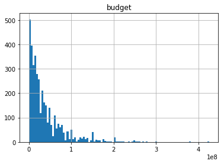

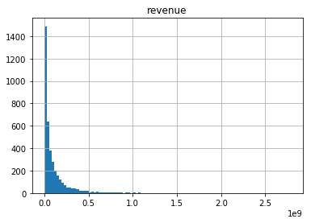

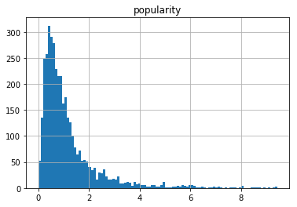

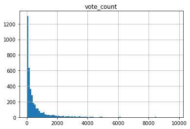

```python
# Histograms
histogram(series = movies, col = "budget")
histogram(series = movies, col = "revenue")
histogram(series = movies, col = "popularity")
histogram(series = movies, col = "vote_count")
```

# Histograms analysis

Histograms follow an expected long-tail distribution, probably an 80-20 rule.

Most movies on this list are not popular